# Time Series Analysis

# 10 Decomposing Time Series

Decomposing a time series involves separating the time series into trend and irregular components. We test both the additive model and multiplicative model.

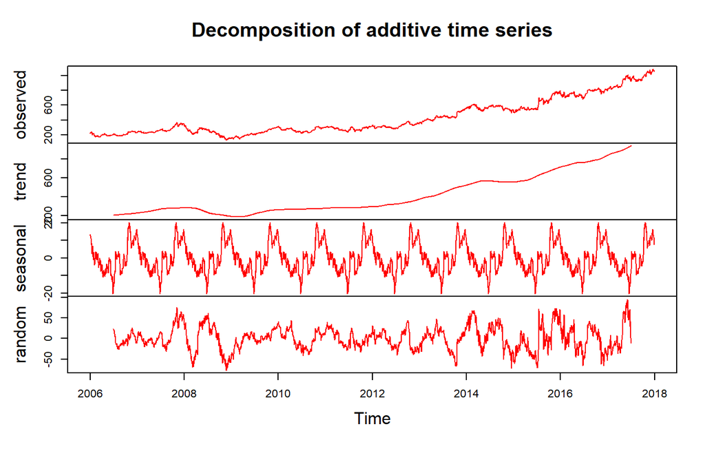

```r
tscomponents_add <- decompose(ts, type = "additive")
tscomponents_mul <- decompose(ts, type = "multiplicative")
plot(tscomponents_add, col = "red")
```

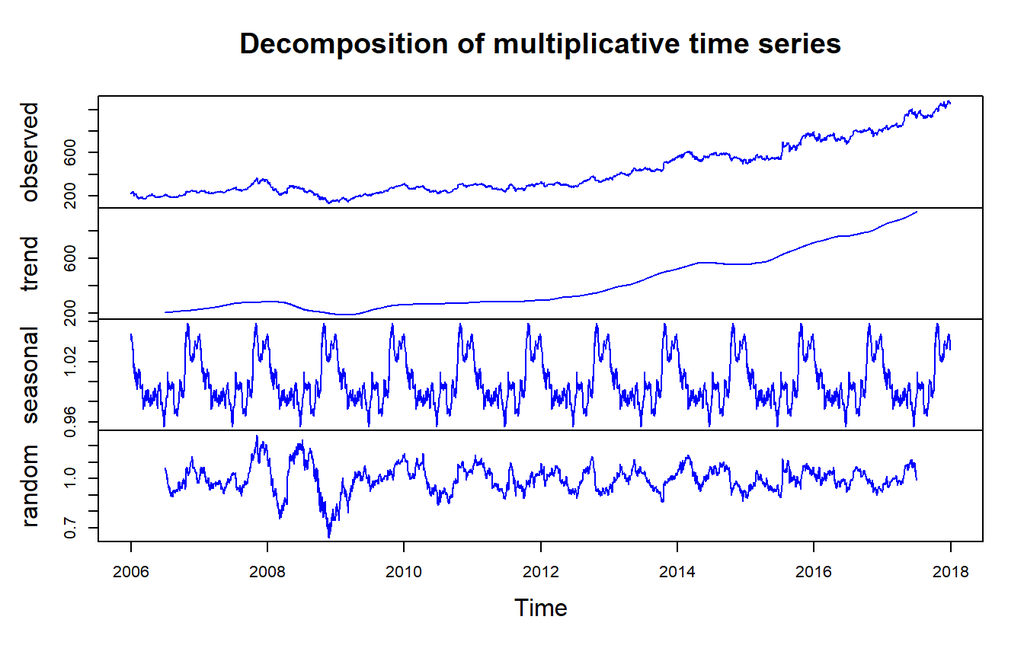

```r
plot(tscomponents_mul, col = "blue")
```

# 11 Differencing a Time Series

Differencing is a common solution used to stationarize the variable. We will perform differencing using R function diff.

Consider fractional difference?

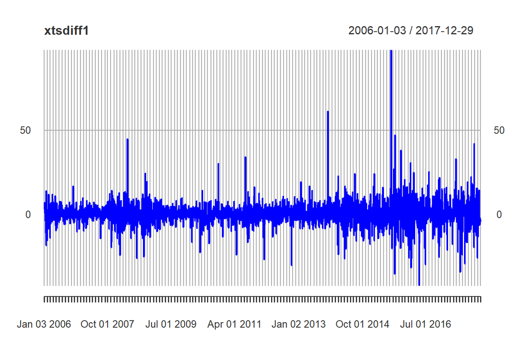

```r
xtsdiff1 <- diff(xts, differences=1)
tsdiff1 <- diff(ts, differences=1)
plot.xts(xtsdiff1, col = "blue")
```

```r
adf.test(tsdiff1, alternative = "stationary", k = 0)
```

```
##
##  Augmented Dickey-Fuller Test
##
## data:  tsdiff1
## Dickey-Fuller = -53.448, Lag order = 0, p-value = 0.01
## alternative hypothesis: stationary
```

```r
findfrequency(xts)          # find dominant frequency of original time series
```

```
## [1] 1
```

```r
findfrequency(xtsdiff1)     # find dominant frequency of differenced time series
```

```
## [1] 18
```

The time series (above) appears to be stationary.

# 12 Selecting a Candidate ARIMA Model

The next step is to select appropriate ARIMA model, which means finding the most appropriate values of p and q for an ARIMA(p,d,q) model. You usually need to examine the correlogram and partial correlogram of the stationary time series for this. To plot a correlogram and partial correlogram, we can use the acf() and pacf() functions in R, respectively.

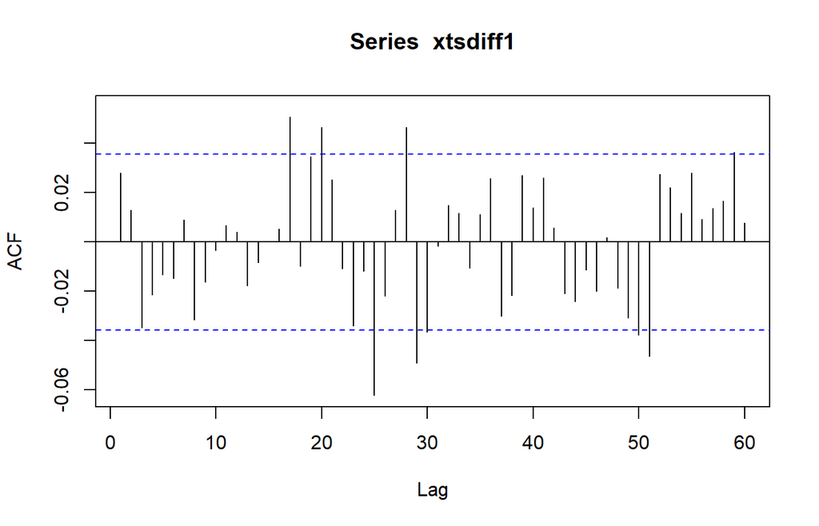

```r
Acf(xtsdiff1, lag.max=60)             # plot a correlogram
```

```r
Acf(xtsdiff1, lag.max=60, plot=FALSE) # get the autocorrelation values
```

```
##
## Autocorrelations of series 'xtsdiff1', by lag
##
##      0      1      2      3      4      5      6      7      8      9
##  1.000  0.028  0.013 -0.035 -0.021 -0.013 -0.015  0.009 -0.031 -0.016
##     10     11     12     13     14     15     16     17     18     19
## -0.004  0.007  0.004 -0.018 -0.008  0.000  0.005  0.051 -0.010  0.035
##     20     21     22     23     24     25     26     27     28     29
##  0.047  0.025 -0.011 -0.034 -0.012 -0.062 -0.022  0.013  0.046 -0.049
##     30     31     32     33     34     35     36     37     38     39
## -0.036 -0.002  0.015  0.012 -0.010  0.011  0.026 -0.030 -0.022  0.027
##     40     41     42     43     44     45     46     47     48     49
##  0.014  0.026  0.006 -0.021 -0.024 -0.011 -0.020  0.002 -0.019 -0.031
##     50     51     52     53     54     55     56     57     58     59
## -0.038 -0.046  0.027  0.022  0.012  0.028  0.009  0.014  0.017  0.036
##     60
##  0.008
```

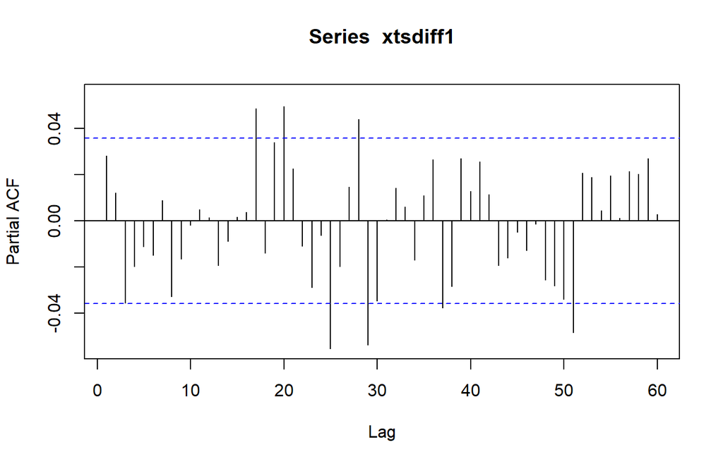

```r
Pacf(xtsdiff1, lag.max=60)             # plot a partial correlogram
```

```r
Pacf(xtsdiff1, lag.max=60, plot=FALSE) # get the partial autocorrelation values
```

```
##
## Partial autocorrelations of series 'xtsdiff1', by lag
##
##      1      2      3      4      5      6      7      8      9     10
##  0.028  0.012 -0.036 -0.020 -0.011 -0.015  0.009 -0.033 -0.016 -0.002
##     11     12     13     14     15     16     17     18     19     20
##  0.005  0.001 -0.019 -0.009  0.002  0.004  0.049 -0.014  0.034  0.050
##     21     22     23     24     25     26     27     28     29     30
##  0.023 -0.011 -0.029 -0.006 -0.055 -0.020  0.015  0.044 -0.054 -0.035
##     31     32     33     34     35     36     37     38     39     40
##  0.001  0.014  0.006 -0.017  0.011  0.026 -0.038 -0.028  0.027  0.013
##     41     42     43     44     45     46     47     48     49     50
##  0.026  0.011 -0.019 -0.016 -0.005 -0.013 -0.002 -0.026 -0.028 -0.034
##     51     52     53     54     55     56     57     58     59     60
## -0.048  0.021  0.019  0.004  0.020  0.001  0.021  0.020  0.027  0.003
```

Now, we could compare the sample ACF and PACF to those of various theoretical ARMA models. Use properties of ACF & PACF as a guide to estimate plausible models and select appropriate p, q and d. Alternative to this is discussed next.

# 13 Fitting an ARIMA Model

R provides a function auto.arima, which returns best ARIMA model according to either AIC, AICc or BIC value. The function conducts a search over possible model within the order constraints provided.

```r
tsarima240 <- auto.arima(head(xts, -240), max.p = 3, max.q = 3, max.d = 3) # excluding last 240 time series as test data
print(tsarima240)
```

```
## Series: head(xts, -240)
## ARIMA(0,1,0) with drift
##
## Coefficients:
##        drift
##       0.2200
## s.e.  0.1264
##
## sigma^2 estimated as 44.43:  log likelihood=-9210.91
## AIC=18425.82   AICc=18425.82   BIC=18437.67
```

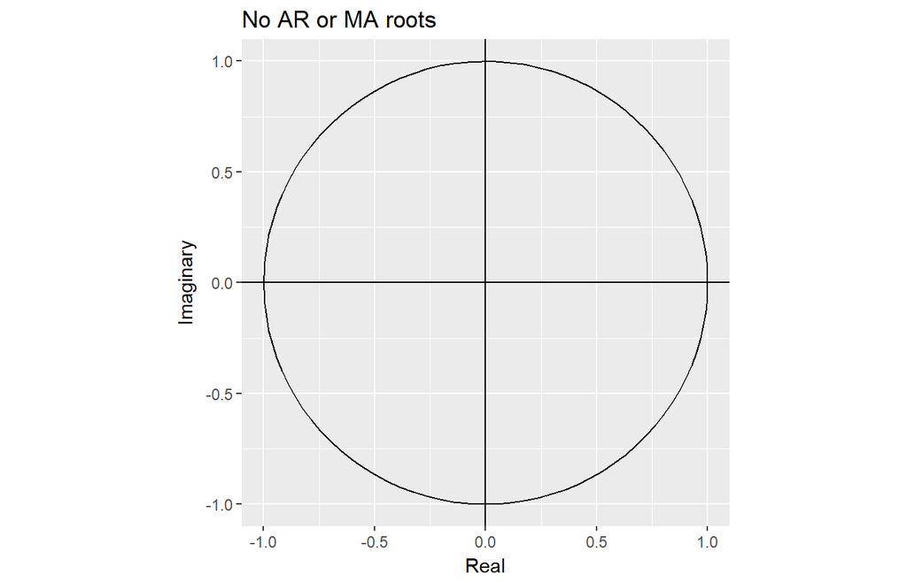

```r
autoplot(tsarima240)
```

```r
tsarima120 <- auto.arima(head(xts, -120), max.p = 3, max.q = 3, max.d = 3) #120
print(tsarima120)
```

```
## Series: head(xts, -120)
## ARIMA(0,1,1) with drift
##
## Coefficients:
##          ma1   drift
##       0.0260  0.2539
## s.e.  0.0183  0.1291
##
## sigma^2 estimated as 45.91:  log likelihood=-9656
## AIC=19317.99   AICc=19318   BIC=19335.91
```

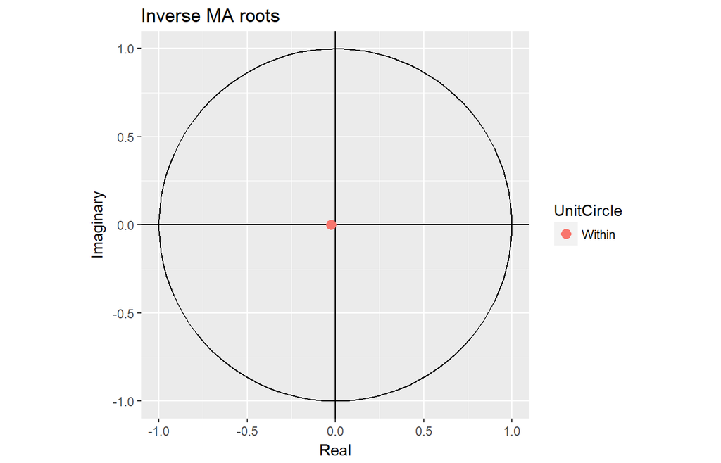

```r
autoplot(tsarima120)
```

```r
tsarima60 <- auto.arima(head(xts, -60), max.p = 3, max.q = 3, max.d = 3) #60
print(tsarima60)
```

```
## Series: head(xts, -60)
## ARIMA(0,1,1) with drift
##
## Coefficients:
##          ma1   drift
##       0.0258  0.2532
## s.e.  0.0181  0.1286
##
## sigma^2 estimated as 46.55:  log likelihood=-9876.46
## AIC=19758.93   AICc=19758.94   BIC=19776.9
```

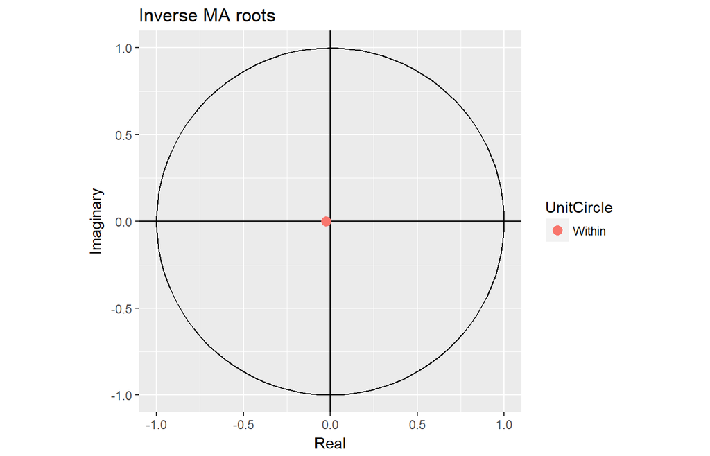

```r
autoplot(tsarima60)
```

```r
tsarima30 <- auto.arima(head(xts, -30), max.p = 3, max.q = 3, max.d = 3) #30
print(tsarima30)
```

```
## Series: head(xts, -30)
## ARIMA(0,1,0) with drift
##
## Coefficients:
##        drift
##       0.2740
## s.e.  0.1258
##
## sigma^2 estimated as 47.28:  log likelihood=-10000.36
## AIC=20004.72   AICc=20004.72   BIC=20016.73
```

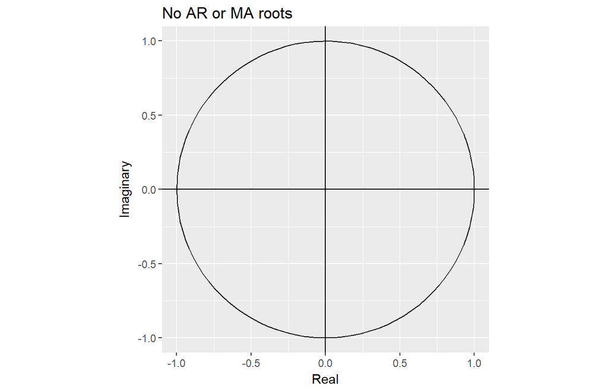

```r
autoplot(tsarima30)
```

```r
tsarima7 <- auto.arima(head(xts, -7), max.p = 3, max.q = 3, max.d = 3)   #7
print(tsarima7)
```

```
## Series: head(xts, -7)
## ARIMA(0,1,1) with drift
##
## Coefficients:
##          ma1   drift
##       0.0264  0.2863
## s.e.  0.0179  0.1293
##
## sigma^2 estimated as 47.8:  log likelihood=-10093.26
## AIC=20192.53   AICc=20192.54   BIC=20210.56
```

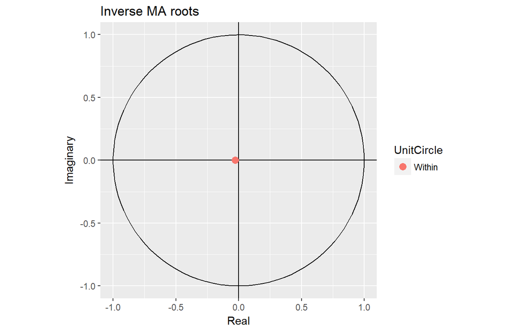

```r
autoplot(tsarima7)
```

# 14 Forecasting using an ARIMA Model

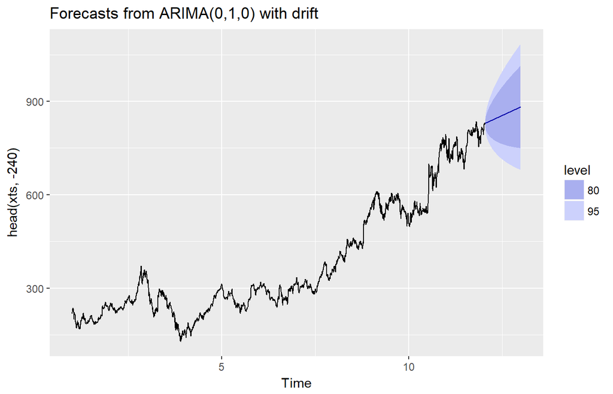

```r
tsforecasts240 <- forecast(tsarima240, h = 240) # forecast the next 240 time series
tsforecasts120 <- forecast(tsarima120, h = 120) # forecast the next 120 time series
tsforecasts60 <- forecast(tsarima60, h = 60) # forecast the next 60 time series
tsforecasts30 <- forecast(tsarima30, h = 30) # forecast the next 30 time series
tsforecasts7 <- forecast(tsarima7, h = 7) # forecast the next 7 time series

autoplot(tsforecasts240)
```

```r
accuracy(tsforecasts240, head(tail(xts, 240), 240))
```

```
##                        ME       RMSE       MAE         MPE     MAPE
## Training set 7.830510e-05   6.662823  4.358564 -0.04023279 1.255910
## Test set     8.958999e+01 107.462582 90.356608  9.04790109 9.141123
##                    MASE       ACF1
## Training set 0.05516544 0.02251657
## Test set     1.14362484         NA
```

```r
accuracy(tsforecasts240, head(tail(xts, 240), 120))
```

```
##                       ME      RMSE       MAE         MPE     MAPE
## Training set 7.83051e-05  6.662823  4.358564 -0.04023279 1.255910
## Test set     5.47361e+01 76.420359 56.269332  5.74033804 5.926781
##                    MASE       ACF1
## Training set 0.05516544 0.02251657
## Test set     0.71218926         NA
```

```r
accuracy(tsforecasts240, head(tail(xts, 240), 60))
```

```
##                        ME      RMSE       MAE         MPE     MAPE
## Training set 0.0000783051  6.662823  4.358564 -0.04023279 1.255910
## Test set     9.1885039597 15.253580 12.254974  1.06607535 1.438961
##                    MASE       ACF1
## Training set 0.05516544 0.02251657
## Test set     0.15510867         NA
```

```r
accuracy(tsforecasts240, head(tail(xts, 240), 30))
```

```
##                        ME      RMSE       MAE         MPE     MAPE
## Training set 0.0000783051  6.662823  4.358564 -0.04023279 1.255910
## Test set     6.1004992801 13.506026 11.611246  0.70604785 1.377561
##                    MASE       ACF1
## Training set 0.05516544 0.02251657
## Test set     0.14696113         NA
```

```r
accuracy(tsforecasts240, head(tail(xts, 240), 7))
```

```
##                        ME      RMSE       MAE         MPE    MAPE
## Training set 7.830510e-05  6.662823  4.358564 -0.04023279 1.25591
## Test set     1.395139e+01 18.322229 15.711395  1.63313782 1.84643
##                    MASE       ACF1
## Training set 0.05516544 0.02251657
## Test set     0.19885586         NA
```

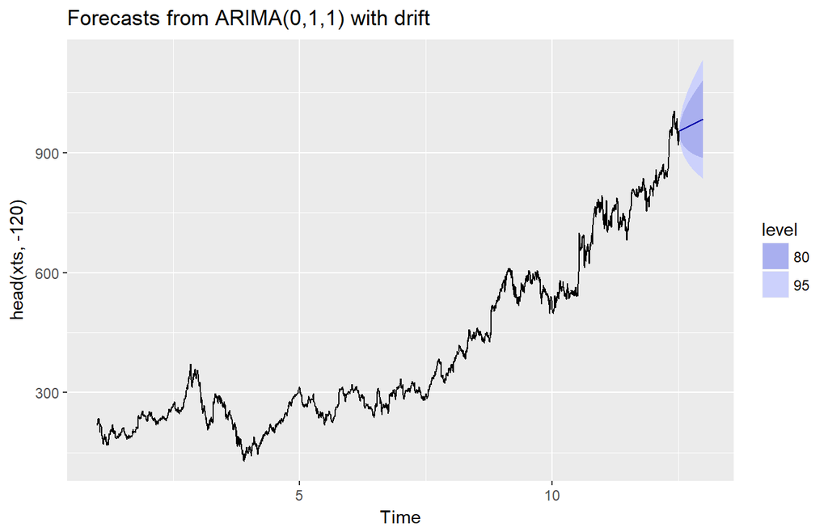

```r
autoplot(tsforecasts120)
```

```r
accuracy(tsforecasts120, head(tail(xts, 120), 120))
```

```
##                        ME     RMSE       MAE         MPE     MAPE
## Training set 8.622115e-05  6.77230  4.444226 -0.04438106 1.233619
## Test set     2.423396e+01 47.76573 39.743165  2.24668716 3.900841
##                   MASE         ACF1
## Training set 0.0536555 0.0003654603
## Test set     0.4798225           NA
```

```r
accuracy(tsforecasts120, head(tail(xts, 120), 60))
```

```
##                         ME     RMSE       MAE         MPE     MAPE
## Training set  8.622115e-05  6.77230  4.444226 -0.04438106 1.233619
## Test set     -1.063842e+01 23.06933 20.380001 -1.15983472 2.148473
##                   MASE         ACF1
## Training set 0.0536555 0.0003654603
## Test set     0.2460494           NA
```

```r
accuracy(tsforecasts120, head(tail(xts, 120), 30))
```

```
##                         ME     RMSE       MAE         MPE     MAPE
## Training set  8.622115e-05  6.77230  4.444226 -0.04438106 1.233619
## Test set     -2.701019e+00 24.38488 21.571816 -0.34178642 2.256133
##                   MASE         ACF1
## Training set 0.0536555 0.0003654603
## Test set     0.2604383           NA
```

```r
accuracy(tsforecasts120, head(tail(xts, 120), 7))
```

```
##                        ME     RMSE       MAE         MPE     MAPE
## Training set 8.622115e-05  6.77230  4.444226 -0.04438106 1.233619
## Test set     2.558612e+01 27.20241 25.586116  2.60125011 2.601250
##                   MASE         ACF1
## Training set 0.0536555 0.0003654603
## Test set     0.3089033           NA
```

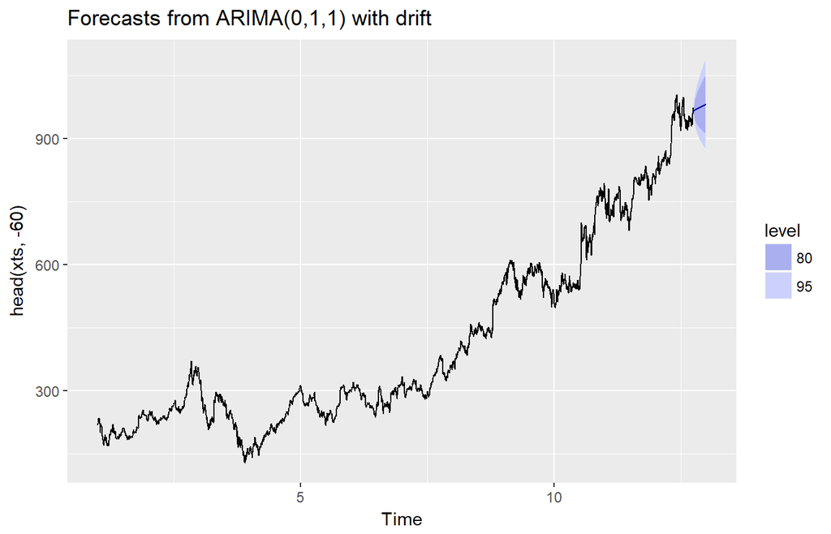

```r
autoplot(tsforecasts60)
```

```r
accuracy(tsforecasts60, head(tail(xts, 60), 60))
```

```
##                        ME      RMSE       MAE         MPE     MAPE
## Training set 2.558875e-05  6.819537  4.490829 -0.04345203 1.222988
## Test set     6.130805e+01 65.547323 61.308054  5.86591739 5.865917
##                   MASE         ACF1
## Training set 0.0531086 0.0004171777
## Test set     0.7250299           NA
```

```r
accuracy(tsforecasts60, head(tail(xts, 60), 30))
```

```
##                        ME      RMSE       MAE         MPE     MAPE
## Training set 2.558875e-05  6.819537  4.490829 -0.04345203 1.222988
## Test set     4.860496e+01 53.330998 48.604964  4.72159500 4.721595
##                   MASE         ACF1
## Training set 0.0531086 0.0004171777
## Test set     0.5748030           NA
```

```r
accuracy(tsforecasts60, head(tail(xts, 60), 7))
```

```
##                        ME      RMSE       MAE         MPE     MAPE
## Training set 2.558875e-05  6.819537  4.490829 -0.04345203 1.222988
## Test set     2.922622e+01 30.361430 29.226218  2.92484821 2.924848
##                   MASE         ACF1
## Training set 0.0531086 0.0004171777
## Test set     0.3456297           NA
```

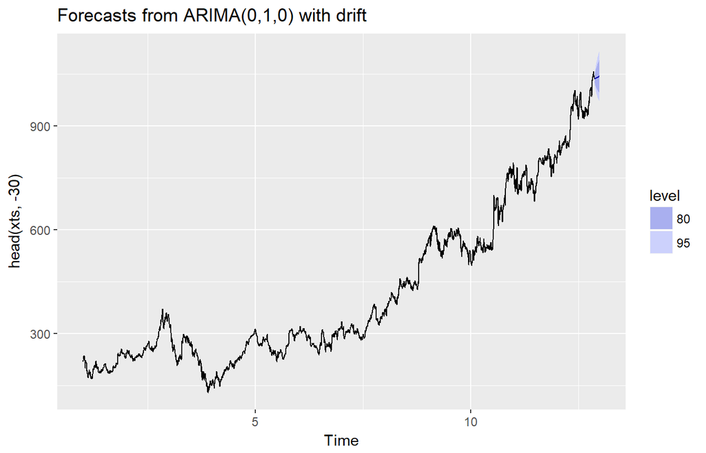

```r
autoplot(tsforecasts30)
```

```r
accuracy(tsforecasts30, head(tail(xts, 30), 30))
```

```
##                        ME      RMSE       MAE         MPE     MAPE
## Training set 7.278553e-05  6.873924  4.512587 -0.04844246 1.217538
## Test set     1.150902e+01 20.032703 16.721867  1.06840749 1.579102
##                    MASE       ACF1
## Training set 0.05248212 0.02360246
## Test set     0.19447805         NA
```

```r
accuracy(tsforecasts30, head(tail(xts, 30), 7))
```

```
##                        ME      RMSE       MAE         MPE     MAPE
## Training set 7.278553e-05  6.873924  4.512587 -0.04844246 1.217538
## Test set     1.246132e+01 16.842987 13.501256  1.17494948 1.275424
##                    MASE       ACF1
## Training set 0.05248212 0.02360246
## Test set     0.15702183         NA
```

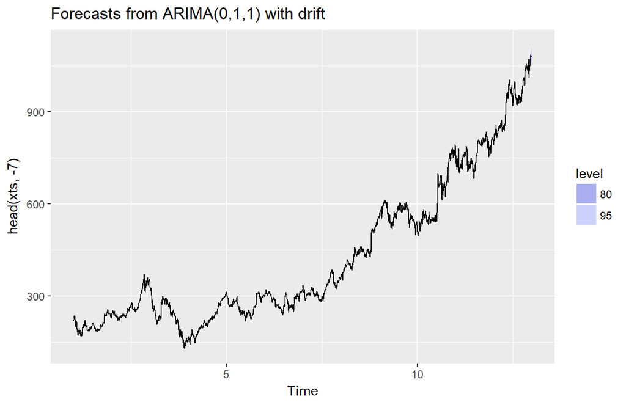

```r
autoplot(tsforecasts7)
```

```r
accuracy(tsforecasts7, head(tail(xts, 7), 7))
```

```
##                         ME      RMSE       MAE         MPE     MAPE
## Training set  2.198881e-05  6.910389  4.548387 -0.04940408 1.215092
## Test set     -1.667274e+01 18.368058 16.672738 -1.57178382 1.571784
##                   MASE         ACF1
## Training set 0.0520307 0.0004004823
## Test set     0.1907257           NA
```

```r
#
# tsdiff1forecasts <- forecast(tsdiff1arima, h = 120) # forecast the next 120 time series
# accuracy(tsdiff1forecasts, tail(xts, 120))
# autoplot(tsdiff1forecasts)
```

```r
# plot.ts(tsforecasts$residuals)            # make time plot of forecast errors
print('tsforecasts240')
```

```
## [1] "tsforecasts240"
```

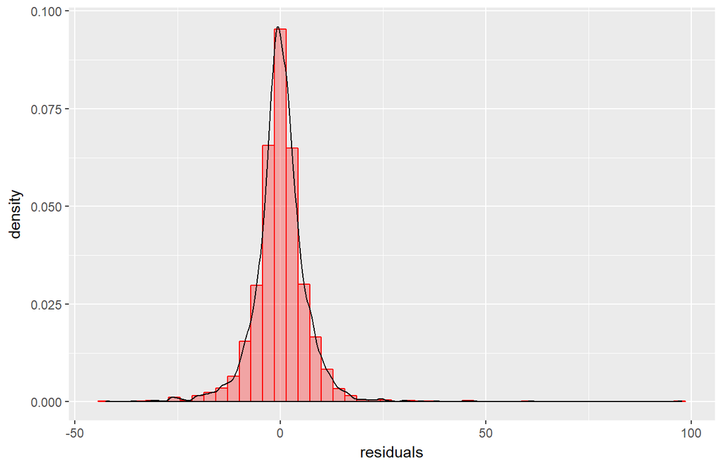

```r
ggplot(data.frame(residuals = tsforecasts240$residuals), aes(residuals)) + geom_histogram(bins = 50, aes(y = ..density..), col = "red", fill = "red", alpha = 0.3) + geom_density()# make a histogram
```

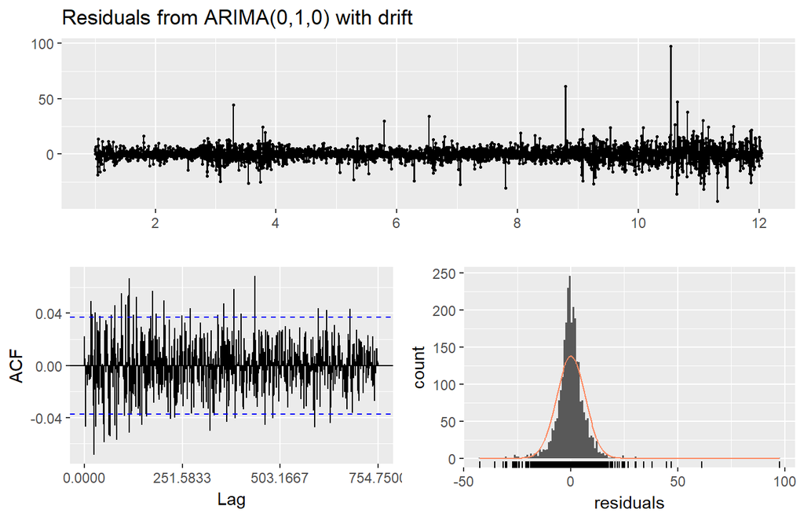

```
##
##  Ljung-Box test
##
## data:  Residuals from ARIMA(0,1,0) with drift
## Q* = 726.5, df = 502.17, p-value = 1.98e-10
##
## Model df: 1.   Total lags used: 503.166666666667
```

```r
checkresiduals(tsforecasts240)
```

```r
print('tsforecasts120')
```

```
## [1] "tsforecasts120"
```

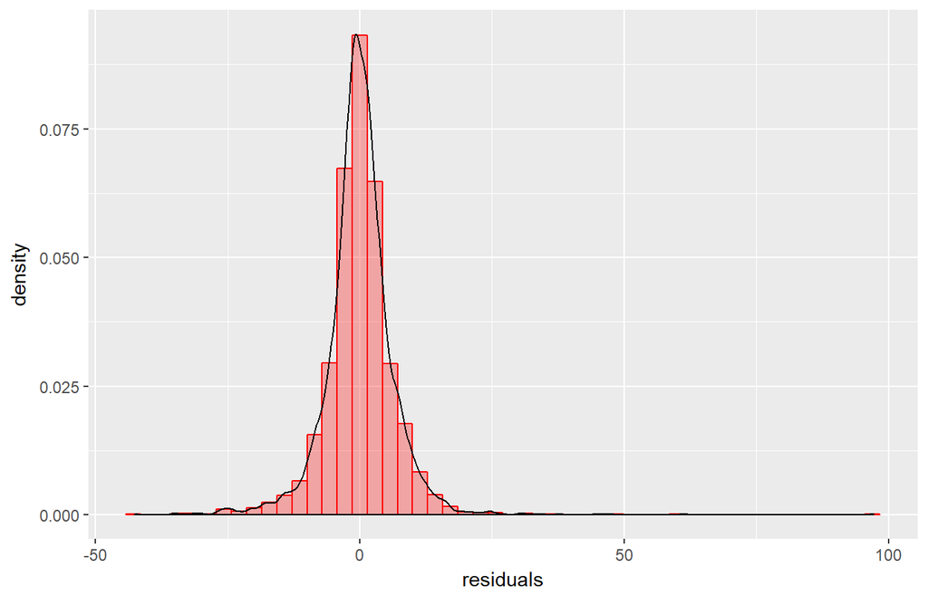

```r
ggplot(data.frame(residuals = tsforecasts120$residuals), aes(residuals)) + geom_histogram(bins = 50, aes(y = ..density..), col = "red", fill = "red", alpha = 0.3) + geom_density()# make a histogram
```

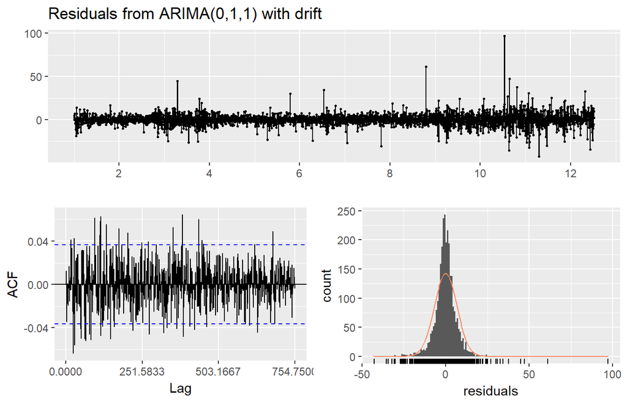

```
##
##  Ljung-Box test
##
## data:  Residuals from ARIMA(0,1,1) with drift
## Q* = 748.08, df = 501.17, p-value = 4.732e-12
##
## Model df: 2.   Total lags used: 503.166666666667
```

```r
checkresiduals(tsforecasts120)
```

```r
print('tsforecasts60')
```

```
## [1] "tsforecasts60"
```

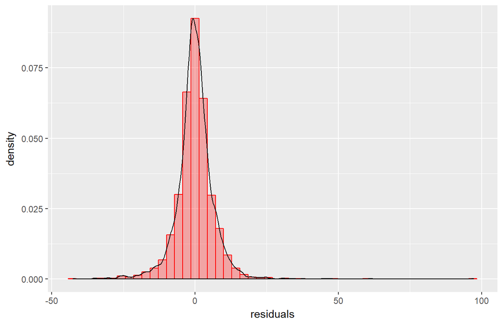

```r
ggplot(data.frame(residuals = tsforecasts60$residuals), aes(residuals)) + geom_histogram(bins = 50, aes(y = ..density..), col = "red", fill = "red", alpha = 0.3) + geom_density()# make a histogram
```

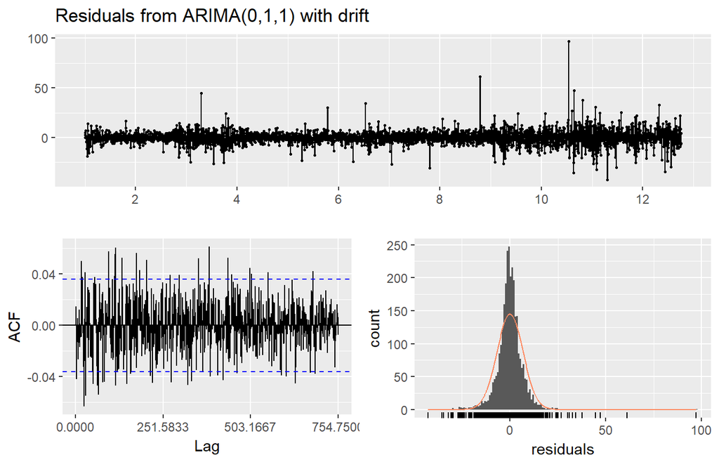

```
##
##  Ljung-Box test
##
## data:  Residuals from ARIMA(0,1,1) with drift
## Q* = 741.62, df = 501.17, p-value = 1.395e-11
##
## Model df: 2.   Total lags used: 503.166666666667
```

```r
checkresiduals(tsforecasts60)
```

```r
print('tsforecasts30')
```

```
## [1] "tsforecasts30"
```

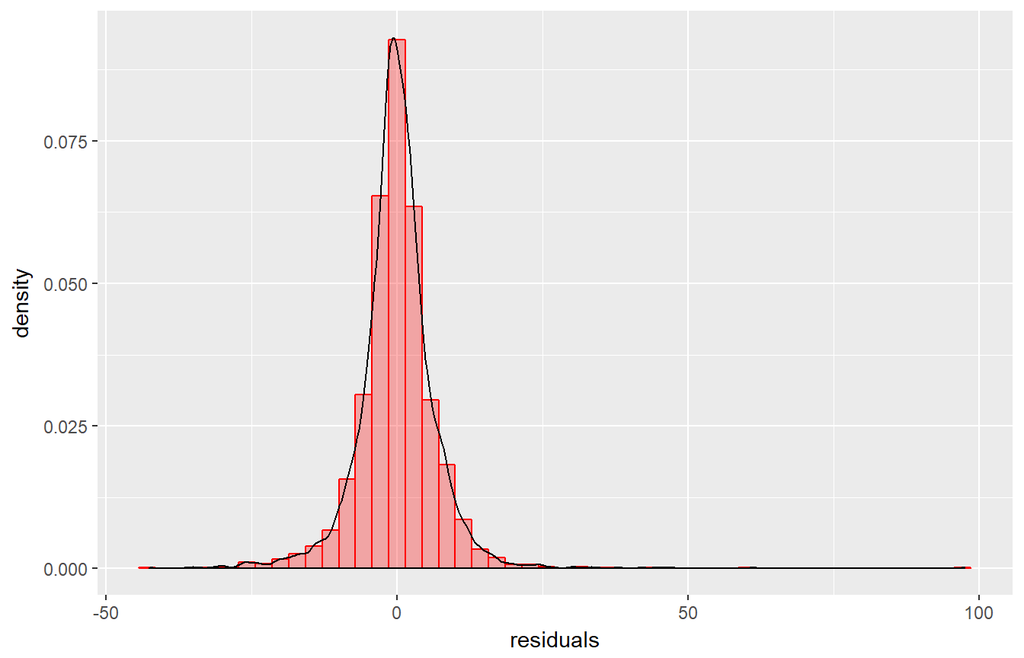

```r
ggplot(data.frame(residuals = tsforecasts30$residuals), aes(residuals)) + geom_histogram(bins = 50, aes(y = ..density..), col = "red", fill = "red", alpha = 0.3) + geom_density()# make a histogram
```

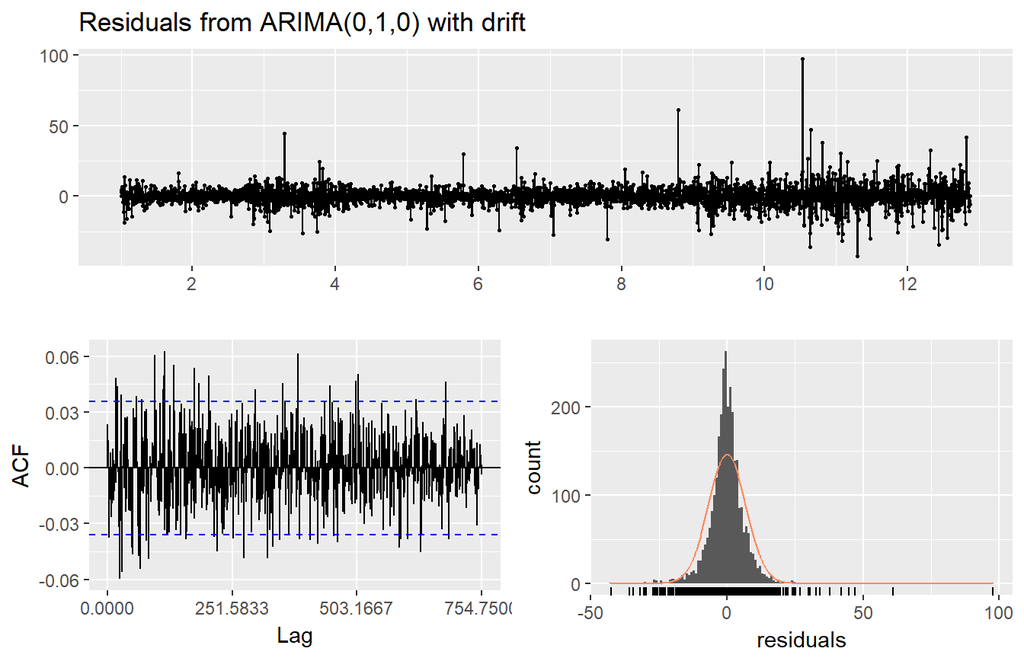

```
##
##  Ljung-Box test
##
## data:  Residuals from ARIMA(0,1,0) with drift
## Q* = 744.82, df = 502.17, p-value = 1.002e-11
##
## Model df: 1.   Total lags used: 503.166666666667
```

```r
checkresiduals(tsforecasts30)
```

```r
print('tsforecasts7')
```

```
## [1] "tsforecasts7"
```

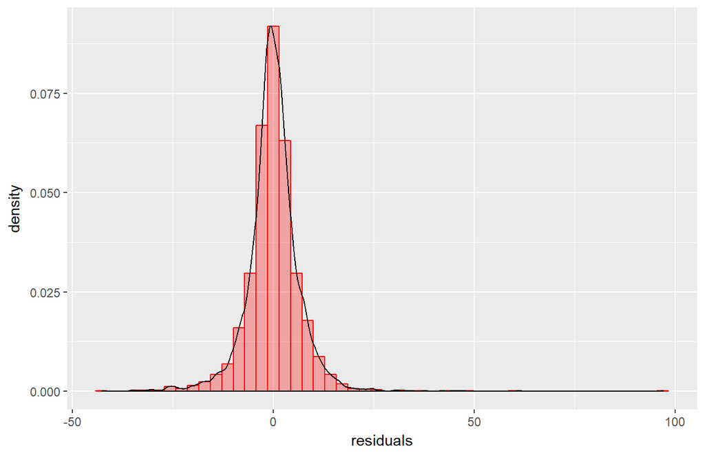

```r
ggplot(data.frame(residuals = tsforecasts7$residuals), aes(residuals)) + geom_histogram(bins = 50, aes(y = ..density..), col = "red", fill = "red", alpha = 0.3) + geom_density()# make a histogram
```

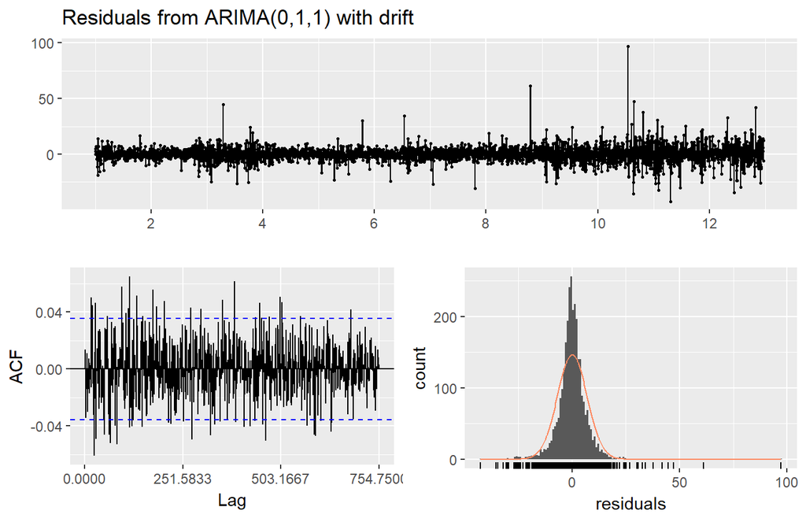

```
##
##  Ljung-Box test
##
## data:  Residuals from ARIMA(0,1,1) with drift
## Q* = 747.93, df = 501.17, p-value = 4.856e-12
##
## Model df: 2.   Total lags used: 503.166666666667
```

```r
checkresiduals(tsforecasts7)
```

```r
#
# ggplot(data.frame(residuals = tsdiff1forecasts$residuals), aes(residuals)) + geom_histogram(bins = 50, aes(y = ..density..), col = "red", fill = "red", alpha = 0.3) + geom_density()# make a histogram
# checkresiduals(tsdiff1forecasts)
```

Here we looked at how to best fit ARIMA model to univariate time series. Next thing that I’ll work on is Multivariate Time Series Forecasting using neural net.

# 15 Test arima_modeling function on the rest companies

```r
source(file="modeling.R")
for (ticker in candidate_ticker){
  if (ticker != 'GOOGL'){
    arima_modeling(xts_list[[ticker]], ts_list[[ticker]], as.character(ticker))
    }
}
```

```
## [1] "IBM"
```

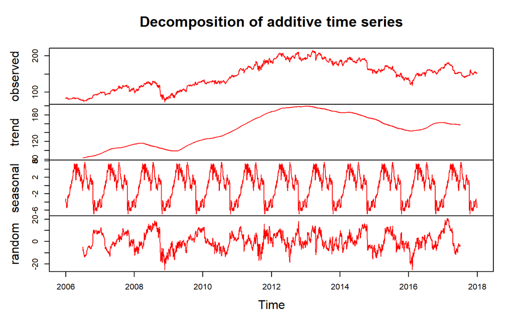

```
## [1] "IBM"
## [1] "Selecting a candidate ARIMA Model"
```

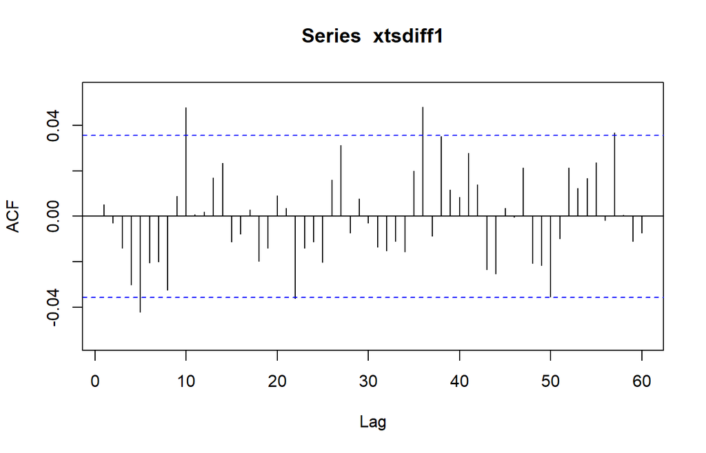

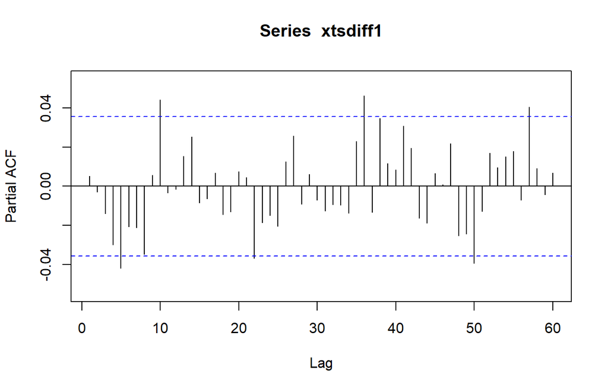

```
## Series: head(xts, -30)
## ARIMA(0,1,0)
##
## sigma^2 estimated as 3.488:  log likelihood=-6108.41
## AIC=12218.82   AICc=12218.82   BIC=12224.82
## [1] "IBM"
## [1] "IBM"
## [1] "IBM"
```

```
##
##  Ljung-Box test
##
## data:  Residuals from ARIMA(0,1,0)
## Q* = 550.98, df = 503.33, p-value = 0.06975
##
## Model df: 0.   Total lags used: 503.333333333333
##
## [1] "BA"
```

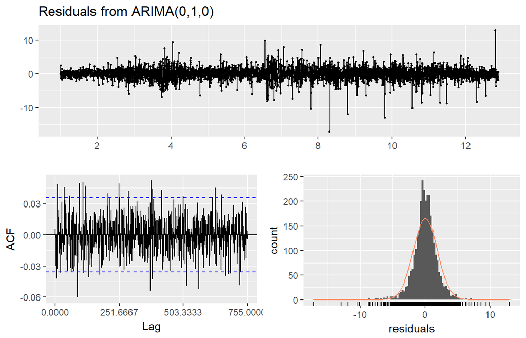

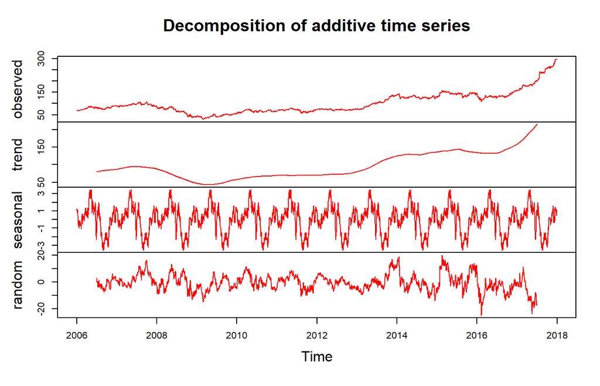

```
## [1] "BA"
## [1] "Selecting a candidate ARIMA Model"
```